# Project: Investigate ford bike Dataset

# thursday shows the highest no. of rides during the week in both subscriber and customer users

# customer has approximatley equal no. of rides during 5 days of week

### (8) what is the relation between user type and age during weekdays?

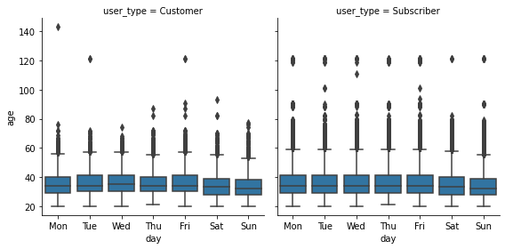

```python
g = sb.FacetGrid(data = bike_clean, col = 'user_type', size = 4)
g.map(sb.boxplot, 'day', 'age');
```

# no effect on user type acc. to age during weekdays

### (9) what is the relation between user type , age and gender?

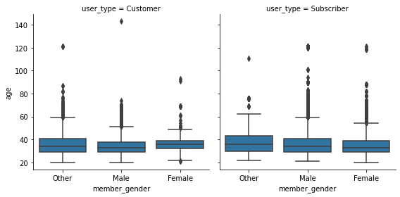

```python
g = sb.FacetGrid(data = bike_clean, col = 'user_type', size = 4)
g.map(sb.boxplot, 'member_gender', 'age');
```

# mean age of female customer is higher than male customer

### (10) what is the relation between user type, age,gender and trip duration?

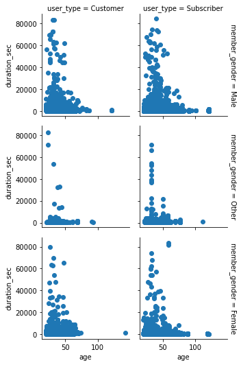

```python
g = sb.FacetGrid(data = bike_clean, col = 'user_type', row = 'member_gender', size = 2.5,
                margin_titles = True)
g.map(plt.scatter, 'age', 'duration_sec');
```

# both male customer and subscriber under 50 has higher duration

# both female customer and subscriber under 50 has higher duration

# female subscriber above 50 shows higher duration than customer

# male subscriber above 50 shows higher duration than customer

## Conclusions

-MARKET ST. AT 10TH ST. is the most popular start point -SAN FRANCISCO CALTRAIN STAION 2 is the popular end point

-people with age 33 are common bike riders people with with age range(25-42) are more likely to use bikes

-people(<25) and (>42) not fammiler wih bike riding

-THURSDAY has the higher rides no.

-the highest no. of bikers use the service regulary

-as expected the youngest bikers more likely to ride for long time

-men age (>50) tend to use bikes more than women in the same age

-rush hours doesn't affect user type

-as expected men and women usage peak still the same during day

-we still have the point young and old people have max activity within(8 am and 15 pm) with different trip duration

-rather than rush hours (1) male has high duration late in the evening (2) female tends to have high trip duration at 9 am

-as expected male subscribers tend to have high no. of rides

-thursday shows the highest no. of rides during the week in both male and female

-thursday shows the highest no. of rides during the week in both subscriber and customer users customer has approximatley equal no. of rides during 5 days of week

-no effect on user type acc. to age during weekdays

-mean age of female customer is higher than male customer

-both male customer and subscriber under 50 has higher duration both female customer and subscriber under 50 has higher duration female subscriber above 50 shows higher duration than customer male subscriber above 50 shows higher duration than customer